# hw4

Ty Darnell

April 3, 2019

```r
tob=fread("tobacco.dat")
cox=fread("BoxCox.dat")
colnames(cox)=c('x','y')
colnames(tob)=c('cotinine','age','bmi', 'educ', 'wet', 'task','lnnsmoke')
tob$wet=factor(tob$wet)
tob$task=factor(tob$task)
```

```r
hw3=fread("FILEN.DAT")
cnames=c("id","year","cohort","date","days","timess","height","weight","age","area","temp","barom","humid","avtrel","avtrsp","avfvc")
colnames(hw3)=cnames
hw3$weight=as.numeric(hw3$weight)
hw3=hw3%>%filter(!is.na(weight))
hw3=hw3%>%mutate(bmi=weight/((height/100)^2))
```

# Problem 1

## Part i)

```r
mod=lm(data = hw3, avfvc ~ height + weight + bmi + area + age + avtrel + avtrsp + avtrel*avtrsp+ temp + barom + humid)
vt=ols_vif_tol(mod)
kable(vt,format="markdown")
```

| Variables | Tolerance | VIF |
| --- | --- | --- |
| height | 0.0021832 | 458.047640 |
| weight | 0.0014216 | 703.446286 |
| bmi | 0.0056354 | 177.450372 |
| area | 0.0007327 | 1364.897524 |
| age | 0.9230672 | 1.083345 |
| avtrel | 0.0017230 | 580.389689 |
| avtrsp | 0.0127562 | 78.393024 |
| temp | 0.0344664 | 29.013786 |
| barom | 0.9442021 | 1.059095 |
| humid | 0.0342854 | 29.166919 |
| avtrel:avtrsp | 0.0012572 | 795.448951 |

Based on the VIF and tolerance, there appears to be collinearity present. Height, Weight, BMI, area, avtrel, avtrsp, avtrel:avtvsp, humid and temp all have high VIF values and low tolerance values. This is a good indication that collinearity is present. This makes sense because BMI is a function of height and weight so it would likely be correlated with both of those variables. Humid and temp are both aspects of weather and could possibly be correlated with one another. Treadmill elevation and speed would both lead to a more rigorous workout, indicating a more cardiovascularly fit subject.

## Part ii)

```r
x1=model.matrix(~ height + weight + bmi + area + age + avtrel + avtrsp + avtrel*avtrsp+ temp + barom + humid,data=hw3)
x2=x1[,-1]
cor1=cor(x2)
kable(cor1,format='markdown')
```

|  | height | weight | bmi | area | age | avtrel | avtrsp | temp | barom | humid | avtrel:avtrsp |
| --- | --- | --- | --- | --- | --- | --- | --- | --- | --- | --- | --- |
| height | 1.0000000 | 0.6116609 | -0.0852012 | 0.8351886 | 0.0153052 | 0.0128742 | 0.3670704 | 0.0563575 | -0.0069256 | 0.0732698 | 0.1252111 |
| weight | 0.6116609 | 1.0000000 | 0.7335584 | 0.9453296 | 0.1335401 | -0.1933416 | 0.1264290 | 0.0373402 | 0.1175006 | 0.0411452 | -0.1288031 |
| bmi | -0.0852012 | 0.7335584 | 1.0000000 | 0.4748857 | 0.1562502 | -0.2489946 | -0.1395588 | -0.0016501 | 0.1490810 | -0.0112990 | -0.2595887 |
| area | 0.8351886 | 0.9453296 | 0.4748857 | 1.0000000 | 0.0946409 | -0.1298201 | 0.2413139 | 0.0505030 | 0.0770311 | 0.0609104 | -0.0379853 |
| age | 0.0153052 | 0.1335401 | 0.1562502 | 0.0946409 | 1.0000000 | -0.0275982 | -0.1047112 | -0.0326110 | -0.0105398 | -0.0544085 | -0.0524688 |
| avtrel | 0.0128742 | -0.1933416 | -0.2489946 | -0.1298201 | -0.0275982 | 1.0000000 | 0.3216408 | -0.0965771 | 0.0272107 | -0.0760644 | 0.9550072 |
| avtrsp | 0.3670704 | 0.1264290 | -0.1395588 | 0.2413139 | -0.1047112 | 0.3216408 | 1.0000000 | 0.0495012 | 0.0425074 | 0.0847005 | 0.5858528 |
| temp | 0.0563575 | 0.0373402 | -0.0016501 | 0.0505030 | -0.0326110 | -0.0965771 | 0.0495012 | 1.0000000 | -0.1142074 | 0.9814017 | -0.0710410 |
| barom | -0.0069256 | 0.1175006 | 0.1490810 | 0.0770311 | -0.0105398 | 0.0272107 | 0.0425074 | -0.1142074 | 1.0000000 | -0.1042636 | 0.0341753 |
| humid | 0.0732698 | 0.0411452 | -0.0112990 | 0.0609104 | -0.0544085 | -0.0760644 | 0.0847005 | 0.9814017 | -0.1042636 | 1.0000000 | -0.0427582 |
| avtrel:avtrsp | 0.1252111 | -0.1288031 | -0.2595887 | -0.0379853 | -0.0524688 | 0.9550072 | 0.5858528 | -0.0710410 | 0.0341753 | -0.0427582 | 1.0000000 |

```r
sscp1=scaledsscp(x1)
kable(sscp1,format='markdown')
```

| (Intercept) | height | weight | bmi | area | age | avtrel | avtrsp | temp | barom | humid | avtrel:avtrsp |
| --- | --- | --- | --- | --- | --- | --- | --- | --- | --- | --- | --- |
| 1.0000000 | 0.9992363 | 0.9933752 | 0.9957513 | 0.9975432 | 0.9912842 | 0.9930116 | 0.9991040 | 0.9945283 | 0.9999726 | 0.9891764 | 0.9905146 |
| 0.9992363 | 1.0000000 | 0.9953631 | 0.9946843 | 0.9990676 | 0.9906059 | 0.9923126 | 0.9989480 | 0.9939988 | 0.9992069 | 0.9888411 | 0.9904304 |
| 0.9933752 | 0.9953631 | 1.0000000 | 0.9969171 | 0.9985449 | 0.9867388 | 0.9838111 | 0.9931001 | 0.9883880 | 0.9934480 | 0.9833171 | 0.9819188 |
| 0.9957513 | 0.9946843 | 0.9969171 | 1.0000000 | 0.9963684 | 0.9889680 | 0.9860868 | 0.9943153 | 0.9902870 | 0.9958257 | 0.9848211 | 0.9830217 |
| 0.9975432 | 0.9990676 | 0.9985449 | 0.9963684 | 1.0000000 | 0.9897222 | 0.9894987 | 0.9973649 | 0.9924545 | 0.9975558 | 0.9873723 | 0.9877155 |
| 0.9912842 | 0.9906059 | 0.9867388 | 0.9889680 | 0.9897222 | 1.0000000 | 0.9839276 | 0.9898122 | 0.9854113 | 0.9912467 | 0.9795032 | 0.9809316 |
| 0.9930116 | 0.9923126 | 0.9838111 | 0.9860868 | 0.9894987 | 0.9839276 | 1.0000000 | 0.9937284 | 0.9863875 | 0.9930082 | 0.9809465 | 0.9990793 |
| 0.9991040 | 0.9989480 | 0.9931001 | 0.9943153 | 0.9973649 | 0.9898122 | 0.9937284 | 1.0000000 | 0.9938561 | 0.9990900 | 0.9888161 | 0.9930341 |
| 0.9945283 | 0.9939988 | 0.9883880 | 0.9902870 | 0.9924545 | 0.9854113 | 0.9863875 | 0.9938561 | 1.0000000 | 0.9944128 | 0.9988075 | 0.9840750 |
| 0.9999726 | 0.9992069 | 0.9934480 | 0.9958257 | 0.9975558 | 0.9912467 | 0.9930082 | 0.9990900 | 0.9944128 | 1.0000000 | 0.9890361 | 0.9905222 |
| 0.9891764 | 0.9888411 | 0.9833171 | 0.9848211 | 0.9873723 | 0.9795032 | 0.9809465 | 0.9888161 | 0.9988075 | 0.9890361 | 1.0000000 | 0.9789316 |
| 0.9905146 | 0.9904304 | 0.9819188 | 0.9830217 | 0.9877155 | 0.9809316 | 0.9990793 | 0.9930341 | 0.9840750 | 0.9905222 | 0.9789316 | 1.0000000 |

```r
ec=eigenvi(sscp1)
kable(ec) %>%
  kable_styling(full_width = F)
```

| Eigenvalues | Condition Index |
| --- | --- |
| 11.9049480 | 1.00000 |
| 0.0360383 | 18.17530 |
| 0.0293709 | 20.13285 |
| 0.0161788 | 27.12628 |
| 0.0066991 | 42.15558 |
| 0.0049049 | 49.26639 |
| 0.0015550 | 87.49891 |
| 0.0002515 | 217.54699 |
| 0.0000375 | 563.68350 |
| 0.0000097 | 1109.51606 |
| 0.0000049 | 1563.89817 |
| 0.0000015 | 2772.25765 |

```r
ec2=eigenvi(cor1)
kable(ec2) %>%
  kable_styling(full_width = F)
```

| Eigenvalues | Condition Index |
| --- | --- |
| 3.0098422 | 1.000000 |
| 2.4478269 | 1.108872 |
| 2.0247648 | 1.219227 |
| 1.1132013 | 1.644315 |
| 1.0132501 | 1.723509 |
| 0.8092794 | 1.928513 |
| 0.5610951 | 2.316080 |
| 0.0177076 | 13.037436 |
| 0.0018737 | 40.079073 |
| 0.0007052 | 65.331723 |
| 0.0004537 | 81.447489 |

Looking at the Scaled SSCP matrix, condition indices greater than 30 (and eigen values close to 0) indicate collinarity with the intercept. There are several CIs greater than 30 (and eigenvalues close to 0), so we know collinarity with the intercept is an issue.

```r
pc.sscp <- prcomp(sscp1)[["rotation"]]
pc.cor <- prcomp(cor1)[["rotation"]]
pc.sscp[,12]
```

```
##   (Intercept)        height        weight           bmi          area
##  0.1473741435  0.4834046812  0.3239142829 -0.0167347071 -0.7151909522
##           age        avtrel        avtrsp          temp         barom
## -0.0004944857 -0.2038318770 -0.2059574809 -0.0270116541 -0.0096174923
##         humid avtrel:avtrsp
##  0.0220843112  0.2064610370
```

Looking at the 12 Priciple Component of the Scaled SSCP matrix, the covariates with the largest deviations from 0 are the intercept, height, weight, area, avtrel, avtrsp and the interaction term avtrel:avtrsp.

```r
pc.cor[,11]
```

```
##        height        weight           bmi          area           age
##   0.507595144   0.014314017   0.310181321  -0.582884584   0.001127961
##        avtrel        avtrsp          temp         barom         humid
##   0.350817108   0.124569696  -0.009805947   0.002276515   0.012268259
## avtrel:avtrsp
##  -0.409062361
```

Looking at the 11th Principle Component of the correlation matrix, the covariates with the largest deviations from 0 are height, BMI, area, avtrel , and avtrel:avtrsp (the interaction term). There appears to be collinearity among these covariates.

# Problem 2

```r
rmod=lm(y~x,cox)
regular=autoplot(rmod)
```

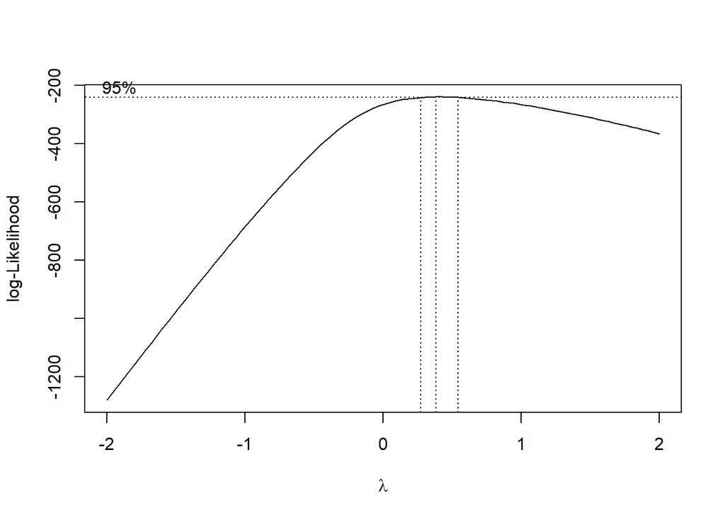

```r
modresid=resid(rmod)
bcox=MASS::boxcox(rmod)
```

```r
EnvStats::boxcox(rmod, optimize = TRUE)
```

```
##
## Results of Box-Cox Transformation
## ---------------------------------
##
## Objective Name:                  PPCC
##
## Linear Model:                    rmod
##
## Sample Size:                     100
##
## Bounds for Optimization:         lower = -2
##                                  upper =  2
##
## Optimal Value:                   lambda = 0.4927123
##
## Value of Objective:              PPCC = 0.9945303
```

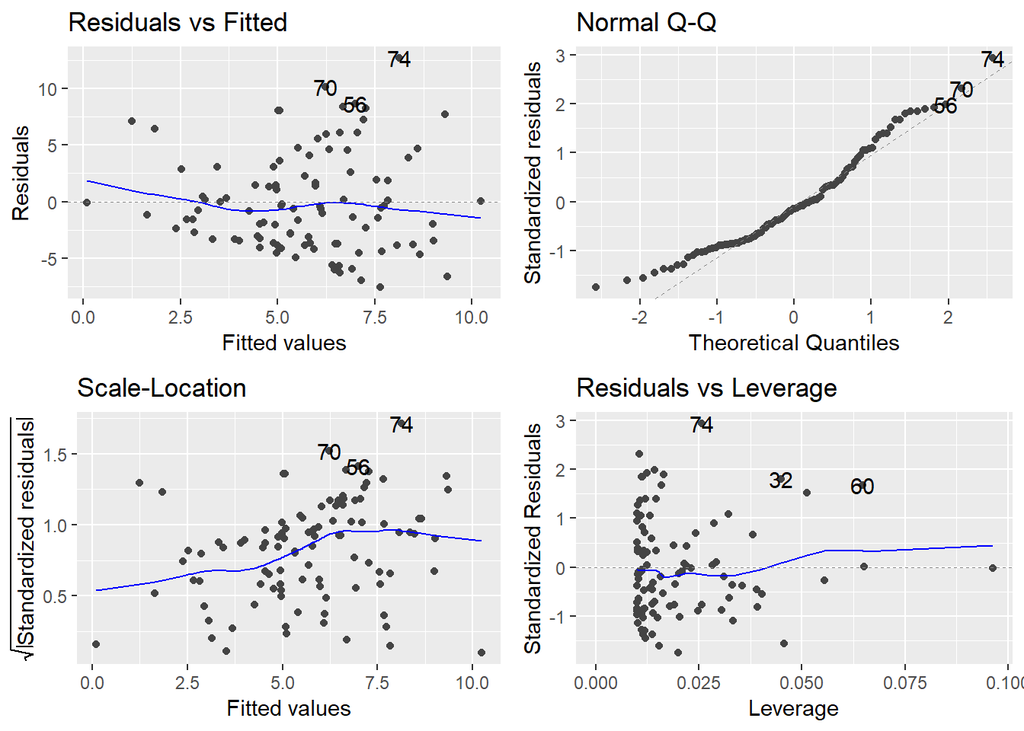

```r
lambda=0.5
cox$yt <- (cox$y^lambda)
cmod <- lm(cox$yt ~ cox$x)
boxcox=autoplot(cmod)
regular
```

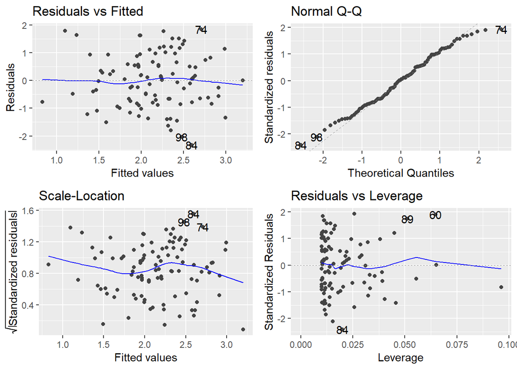

```r
boxcox
```

Using $\pi=.5$ since the optimal value for $\pi$ rounds to .5

Comparing the diagnostic plots between the regular and transformed models, the residuals of the transformed model appear more randomly distributed and the qq plot of the transformed model appears more normal than the untransformed model.

# Problem 3

## Bullet 1) One-Way ANOVA

### Dash 1)

```r
tob1=tob%>%mutate(logcot=log(cotinine))
```

```r
a=aov(logcot~task,data=tob1)
anova1=anova(a)
kable(anova1,format="markdown")
```

|  | Df | Sum Sq | Mean Sq | F value | Pr(>F) |
| --- | --- | --- | --- | --- | --- |
| task | 3 | 790.4454 | 263.481800 | 116.2033 | 0 |
| Residuals | 690 | 1564.5211 | 2.267422 | NA | NA |

$H_0:$ all $\beta$s are equal

$H_A:$ least one of the $\beta_i$s is not equal to the others

From the anova table, the F-statistic is 116.2 on 3 $df_{mod}$ and 690 $df_{Error}$ $pvalue<.00001$ Thus at the $\alpha=.05$ level, reject $H_0$ There is sufficient evidence to suggest that at least one of the tasks has a different log cotinine level than the others, thus not all cell means are equal.

### Dash 2)

```r
pairwise=pairw.anova(tob1$logcot,tob1$task,method="scheffe")
pairsum=summary(glht(a, linfct = mcp(task = "Tukey")))
tvals=pairsum[["test"]][["tstat"]]
fvals=tvals^2
fvals=as.data.frame(fvals)$fvals
sch=pairwise[4]$summary
schtab=cbind(sch,fvals)
kable(schtab,format="markdown")
```

[output not shown]

### Dash 3)

```r
modc=lm(logcot~task-1,data=tob1)
cm=summary(modc)[4]
kable(cm,format="markdown")
```

|  | Estimate | Std. Error | t value | Pr(>\|t\|) |
| --- | --- | --- | --- | --- |
| task1 | 4.508557 | 0.1022201 | 44.10636 | 0 |
| task2 | 3.587775 | 0.1812765 | 19.79172 | 0 |
| task3 | 2.834709 | 0.1039098 | 27.28047 | 0 |
| task4 | 1.809304 | 0.1070123 | 16.90745 | 0 |

For cell mean coding, the parameter estimates are the cell means for each group

$H_0: \mu_1=(1/3)(\mu_2+\mu_3+\mu_4)$

which is the same as:

$H_0: \mu_1-(1/3)\mu_2-(1/3)\mu_3-(1/3)\mu_4=0$

$C=\begin{bmatrix}1& -1/3 &-1/3& -1/3\end{bmatrix}$

$\theta_0=0$

For reference cell coding:

```r
mod=lm(logcot~task,data=tob1)
est=summary(mod)$coef
kable(est,format="markdown")
```

|  | Estimate | Std. Error | t value | Pr(>\|t\|) |
| --- | --- | --- | --- | --- |
| (Intercept) | 4.5085566 | 0.1022201 | 44.106361 | 0.00e+00 |
| task2 | -0.9207815 | 0.2081109 | -4.424476 | 1.12e-05 |
| task3 | -1.6738481 | 0.1457607 | -11.483531 | 0.00e+00 |
| task4 | -2.6992523 | 0.1479884 | -18.239617 | 0.00e+00 |

$\theta_0=0$

task 1 is the reference group, the parameter estimates are the difference between levels in each group and the reference, which is the intercept. $\beta_i$ is the difference between mean log cotinine levels of task i and task 1, for i =2, 3, 4 and $\beta_1$ is the mean log cotinine level among task 1.

## Bullet 2) Two-Way ANOVA

Two-way ANOVA model with Cell Mean coding:

$y=\beta_1I_{W0,T1}+\beta_2I_{W1,T1}+\beta_3I_{W0,T2}+\beta_4I_{W1,T2}+\beta_5I_{W0,T3}+\beta_6I_{W1,T3}+\beta_7I_{W0,T4}+\beta_8I_{W1,T4}$

y= logcot $I_{Ti,Wj}$ is the indicator function corresponding to the $i_{th}$ task and $j_{th}$ wet

```r
mod2= lm(logcot ~ -1 + w0t1 + w1t1 + w0t2 + w1t2 + w0t3 + w1t3 + w0t4 + w1t4, data = tob2)
fullmod=summary(mod2)$coefficients
Parameter=c('B1','B2','B3','B4','B5','B6','B7','B8')
res=cbind(fullmod,Parameter)
kable(res,format="markdown")
```

|  | Estimate | Std. Error | t value | Pr(>\|t\|) | Parameter |
| --- | --- | --- | --- | --- | --- |
| w0t1 | 4.2693372727113 | 0.185471208377273 | 23.0188680500043 | 2.5483389868162e-87 | B1 |
| w1t1 | 4.61311603661602 | 0.122619628384473 | 37.6213506548203 | 6.45977235990406e-169 | B2 |
| w0t2 | 3.54274757148594 | 0.227154911250865 | 15.5961742230323 | 3.66523958186942e-47 | B3 |
| w1t2 | 3.66702358263235 | 0.30135504396224 | 12.1684493294621 | 5.52861082694318e-31 | B4 |
| w0t3 | 2.68818516193764 | 0.215253602830172 | 12.4884560657437 | 2.14265876098874e-32 | B5 |
| w1t3 | 2.8793026128424 | 0.118750523059642 | 24.2466520454507 | 2.80890602282131e-94 | B6 |
| w0t4 | 1.808888748335 | 0.123856160116884 | 14.6047539874314 | 2.91178235253167e-42 | B7 |
| w1t4 | 1.81053437130363 | 0.21309019513047 | 8.49656348662631 | 1.21184869601382e-16 | B8 |

Each parameter represents the mean logcot level for the combination of wet and task levels

This is unbalanced since every cell does not have the same number of observational units.

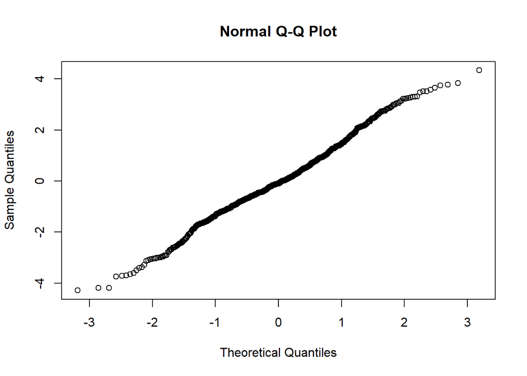

```r
qqnorm(mod2$residuals)
```

```r
leveneTest(logcot ~ task*wet, data = tob2, center=median)
```

```
## Levene's Test for Homogeneity of Variance (center = median)
##        Df F value    Pr(>F)
## group   7  18.635 < 2.2e-16 ***
##       686
## ---
## Signif. codes:  0 '***' 0.001 '**' 0.01 '*' 0.05 '.' 0.1 ' ' 1
```

The independence assumption is based on the design and sampling scheme and does not appear to have been violated.

From the qq plot, we can see that the gaussian errors assumption is met.

The Levene Test returns a p-value very close to 0, thus reject the null hypothesis of equal variances, and conclude that there is a difference between the variances in the population. Thus the homogeniety of variances assumption is not met. We should be careful using this model as a result.

## Bullet 3) The Full Model in Every Cell

### Dash 1)

$y=\beta_1+\beta_2I_{T2}+\beta_3I_{T3}+\beta_4I_{T4}+\beta_5x+\beta_6I_{T2}x+\beta_7I_{T3}x+\beta_8I_{T4}x$

y=logcot x=lnnsmoke $I_{Ti}$ is the indicator function corresponding to the $i_th$ task

```r
mod3 = lm(logcot ~task + task*lnnsmoke, data = tob3)
ecell=summary(mod3)$coefficients
kable(ecell,format="markdown")
```

|  | Estimate | Std. Error | t value | Pr(>\|t\|) |
| --- | --- | --- | --- | --- |
| (Intercept) | 4.3344142 | 0.0931990 | 46.507113 | 0.0000000 |
| task2 | -1.2210290 | 0.1908615 | -6.397462 | 0.0000000 |
| task3 | -2.3221216 | 0.1356146 | -17.122953 | 0.0000000 |
| task4 | -3.4207011 | 0.1335689 | -25.610007 | 0.0000000 |
| lnnsmoke | 0.2945994 | 0.0886913 | 3.321625 | 0.0009424 |
| task2:lnnsmoke | 0.4274696 | 0.1699337 | 2.515508 | 0.0121134 |
| task3:lnnsmoke | 0.9359153 | 0.1259283 | 7.432126 | 0.0000000 |
| task4:lnnsmoke | 1.4843094 | 0.1353184 | 10.969010 | 0.0000000 |

The intercept $\beta_1$ estimate is mean of logcot for priming when lnnsmoke=0

The task2 estimate for $\beta_2$ is the difference between the mean of logcot for barning and for priming when lnnsmoke is 0.

The task3 estimate for $\beta_3$ is the difference between the mean logcot for topping and for priming when lnnsmoke is 0

The task4 estimate for $\beta_4$ is the difference between the mean of logcot for other task and for priming when lnnsmoke is 0 The lnnsmoke estimate for $\beta_5$ is the mean increase in logcot when lnnsmoke increases by 1 for subjects in priming

the last 3 estimates are for $\beta_6,\beta_7,\beta_8$ mean increase in logcot when lnnsmoke increases by 1 for subjects in barning, topping, and other.

### Dash 2)

Testing whether task is related to logcot level

We want to test whether the intercepts for each task and the slopes for each task are equal to each other

$H_0: \beta_2=0, \beta_3=0, \beta_4=0, \beta_6=0, \beta_7=0, \beta_8=0$

Using overall F test

```r
C = matrix(c(
0, 0, 0, 0, 0, 0,
1, 0, 0, 0, 0, 0,
0, 1, 0, 0, 0, 0,
0, 0, 1, 0, 0, 0,
0, 0, 0, 0, 0, 0,
0, 0, 0, 1, 0, 0,
0, 0, 0, 0, 1, 0,
0, 0, 0, 0, 0, 1),
nrow = 6)
linearHypothesis(mod3, C)
```

```
## Linear hypothesis test
##
## Hypothesis:
## task2 = 0
## task3 = 0
## task4 = 0
## task2:lnnsmoke = 0
## task3:lnnsmoke = 0
## task4:lnnsmoke = 0
##
## Model 1: restricted model
## Model 2: logcot ~ task + task * lnnsmoke
##
##   Res.Df     RSS Df Sum of Sq      F    Pr(>F)
## 1    692 1806.03
## 2    686  883.86  6    922.17 119.29 < 2.2e-16 ***
## ---
## Signif. codes:  0 '***' 0.001 '**' 0.01 '*' 0.05 '.' 0.1 ' ' 1
```

Since $pvalue < .00001$ , reject $H_0$. There is sufficient evidence that the slopes for all four tasks are not equal and that the intercepts for all four tasks are not equal.

Step down test: testing where all intercepts are equal

```r
C = matrix(
c(0, 0, 0,
1, 0, 0,
0, 1, 0,
0, 0, 1,
0, 0, 0,
0, 0, 0,
0, 0, 0,
0, 0, 0), nrow = 3)
linearHypothesis(mod3, C)
```

```
## Linear hypothesis test
##
## Hypothesis:
## task2 = 0
## task3 = 0
## task4 = 0
##
## Model 1: restricted model
## Model 2: logcot ~ task + task * lnnsmoke
##
##   Res.Df     RSS Df Sum of Sq      F    Pr(>F)
## 1    689 1785.88
## 2    686  883.86  3    902.01 233.36 < 2.2e-16 ***
## ---
## Signif. codes:  0 '***' 0.001 '**' 0.01 '*' 0.05 '.' 0.1 ' ' 1
```

Since $pvalue < .00001$ reject $H_0$

There is sufficient evidence that the intercepts for all four tasks are not equal

Now testing whether all slopes are equal

```r
C = matrix(
c(0, 0, 0,
0, 0, 0,
0, 0, 0,
0, 0, 0,
0, 0, 0,
1, 0, 0,
0, 1, 0,
0, 0, 1), nrow = 3)
linearHypothesis(mod3, C)
```

```
## Linear hypothesis test
##
## Hypothesis:
## task2:lnnsmoke = 0
## task3:lnnsmoke = 0
## task4:lnnsmoke = 0
##
## Model 1: restricted model
## Model 2: logcot ~ task + task * lnnsmoke
##
##   Res.Df     RSS Df Sum of Sq      F    Pr(>F)
## 1    689 1053.51
## 2    686  883.86  3    169.64 43.889 < 2.2e-16 ***
## ---
## Signif. codes:  0 '***' 0.001 '**' 0.01 '*' 0.05 '.' 0.1 ' ' 1
```

Since $pvalue<.00001$ reject $H_0$

There is sufficient evidence that the slopes for all four tasks are not equal.